# 4_figures and tables

# Figure 1 - map of sites from ArcGIS

Could color sites by cross-validation subsets?

# figure 2 temperature index

Load temp.dm.may data frame with May data in it.

(plot similar to Letcher et al. so readers understand temp index.)

Figure 2. Example of mean daily stream temperatures (black) and air temperatures (red) for the mainstem Anchor River below the confluence of the north and south forks (CIK14) in 2008 and 2014 (top panel). Temperature index values for the same site and years are shown in the bottom panel with deviations in May indicating a poor relationship between air and stream temperatures.

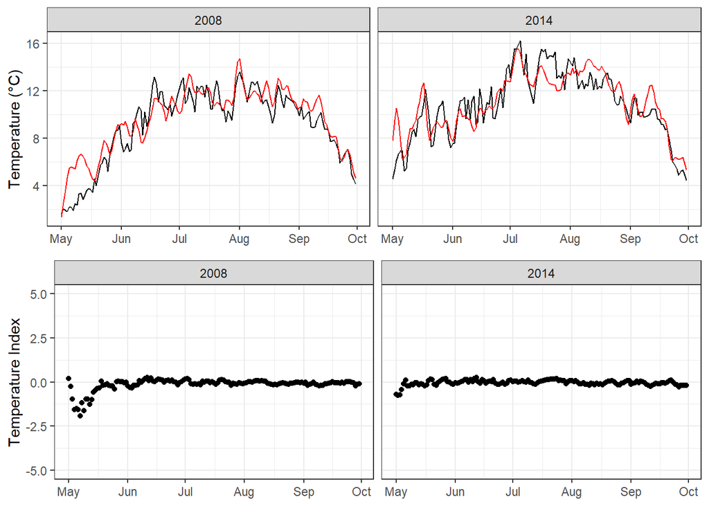

# Fig 3 descriptive model figures

Load global model.

[CURRENTLY NOT RUN HAVING PROBLEMS WITH SJPLOT]

# figure 4 cross-validation results

Load results

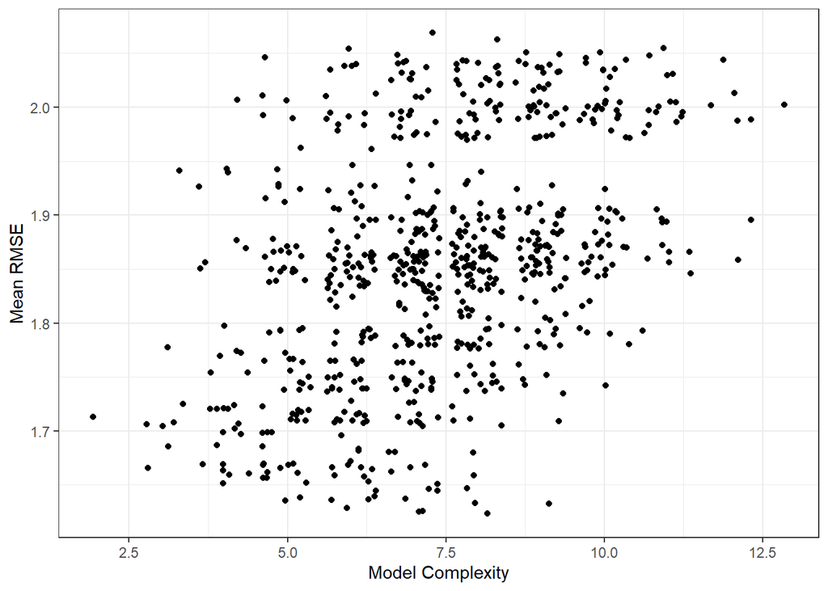

# figure 5 boxplot of rmse by xval group

Figure 5. Boxplots of prediction errors for all possible models by cross-validation subset. RMSE = root mean squared error.

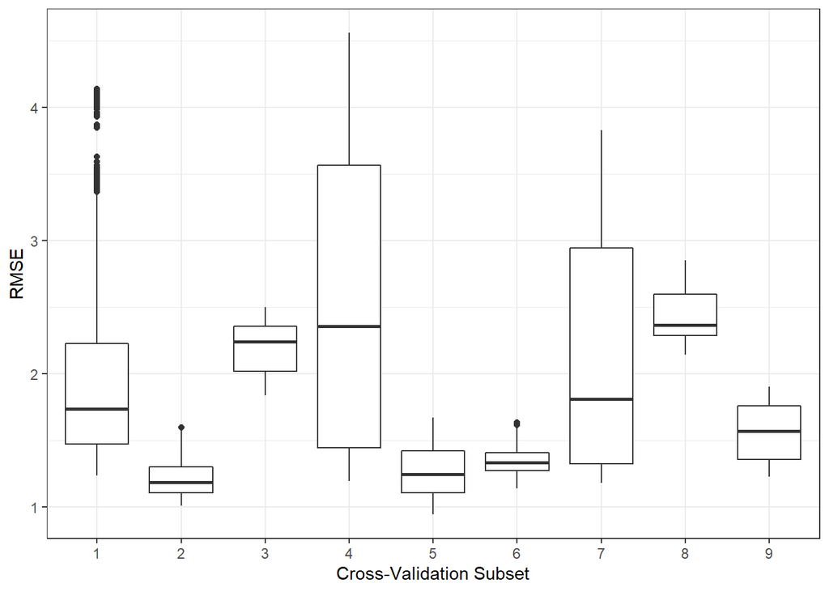

# Summary tables for descriptive and predictive models

Descriptive model selected by AIC.

|  | mean |  |  |
| --- | --- | --- | --- |
| Predictors | Estimates | CI | p |
| (Intercept) | 10.9235 | 10.5532 – 11.2938 | **<0.001** |
| tair3c | 0.6630 | 0.6357 – 0.6903 | **<0.001** |
| tair3c^2 | 0.0125 | 0.0088 – 0.0162 | **<0.001** |
| jdc | -0.0119 | -0.0145 – -0.0093 | **<0.001** |
| jdc^2 | -0.0004 | -0.0004 – -0.0004 | **<0.001** |
| sweA1c | -0.0020 | -0.0027 – -0.0013 | **<0.001** |
| wetlandc | 0.0047 | 0.0024 – 0.0070 | **<0.001** |
| shrubc | 0.0088 | 0.0061 – 0.0116 | **<0.001** |
| catchment_elev_mnc | -0.0058 | -0.0065 – -0.0052 | **<0.001** |
| cont_areac | 0.0034 | 0.0031 – 0.0036 | **<0.001** |
| season [spring] | 0.0681 | -0.1047 – 0.2409 | 0.440 |
| sweA1c * wetlandc | 0.0002 | 0.0001 – 0.0002 | **<0.001** |
| tair3c * season [spring] | 0.1017 | 0.0611 – 0.1423 | **<0.001** |
| Random Effects |  |  |  |
| σ<sup>2</sup> | 1.68 |  |  |
| τ<sub>00</sub> <sub>HUC_name</sub> | 0.23 |  |  |
| ICC | 0.12 |  |  |
| N <sub>HUC_name</sub> | 7 |  |  |
| Observations | 6486 |  |  |
| Marginal R<sup>2</sup> / Conditional R<sup>2</sup> | 0.781 / 0.807 |  |  |

Predictive model selected by cross-validation error.

|  | mean |  |  |
| --- | --- | --- | --- |
| Predictors | Estimates | CI | p |
| (Intercept) | 10.3216 | 9.9138 – 10.7294 | **<0.001** |
| catchment_elev_mnc | -0.0114 | -0.0120 – -0.0108 | **<0.001** |
| season [spring] | 0.3492 | 0.2731 – 0.4254 | **<0.001** |
| sweA1c | -0.0040 | -0.0048 – -0.0033 | **<0.001** |
| tair3c | 0.8181 | 0.8035 – 0.8328 | **<0.001** |
| Random Effects |  |  |  |
| σ<sup>2</sup> | 2.15 |  |  |
| τ<sub>00</sub> <sub>HUC_name</sub> | 0.29 |  |  |
| ICC | 0.12 |  |  |
| N <sub>HUC_name</sub> | 7 |  |  |
| Observations | 6486 |  |  |
| Marginal R<sup>2</sup> / Conditional R<sup>2</sup> | 0.712 / 0.746 |  |  |

# Thermal metrics for historic data

Import metrics file and spatial data for species by catchment.

merge.

Time series of mean july temperature for each year averaged for each subwatershed. Not very interesting.

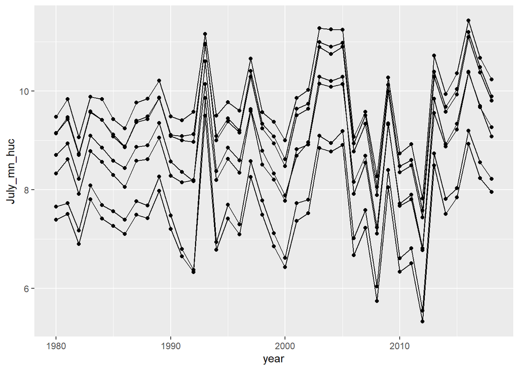

Distributions of decadal average mean july temperature by catchment.

# Figure 6 distribution of mean july temperatures by decade for historical data

Figure 6. Distributions of mean July temperature by decade for all catchments in the Anchor-Stariski watersheds. Vertical dashed lines indicate the average of mean July temperatures by decade across all catchments.

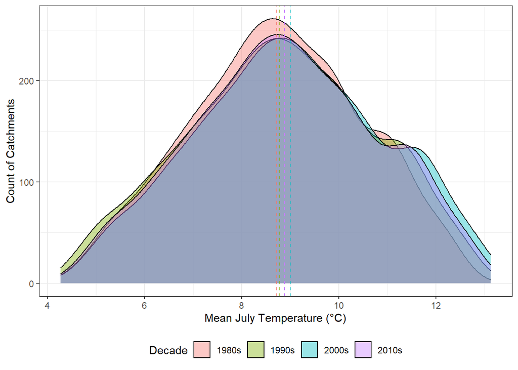

Why is there so little change across decades? NOAA data indicates 0.6 F increase/decade for kenai pen borough. 0.6 * 3 = 1.8 over 30 years. 1.8 * 5/9 = 1 deg C change. The air temp coefficient is ~ 0.8 so that would be 0.8 deg C change on average.

Check air temperature to see if it is increasing over the 30-year period, like the NOAA data indicate (1 deg C change from 1980-2020). Use rca_id = 932, outlet of Anchor. Looks accurate.

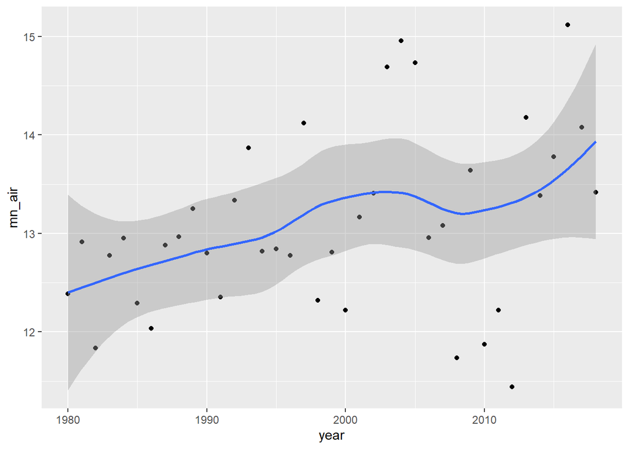

Did snow pack increase over the same 30 years? Yes, this could be offsetting the air temperature increases given that both are in the predictive model.

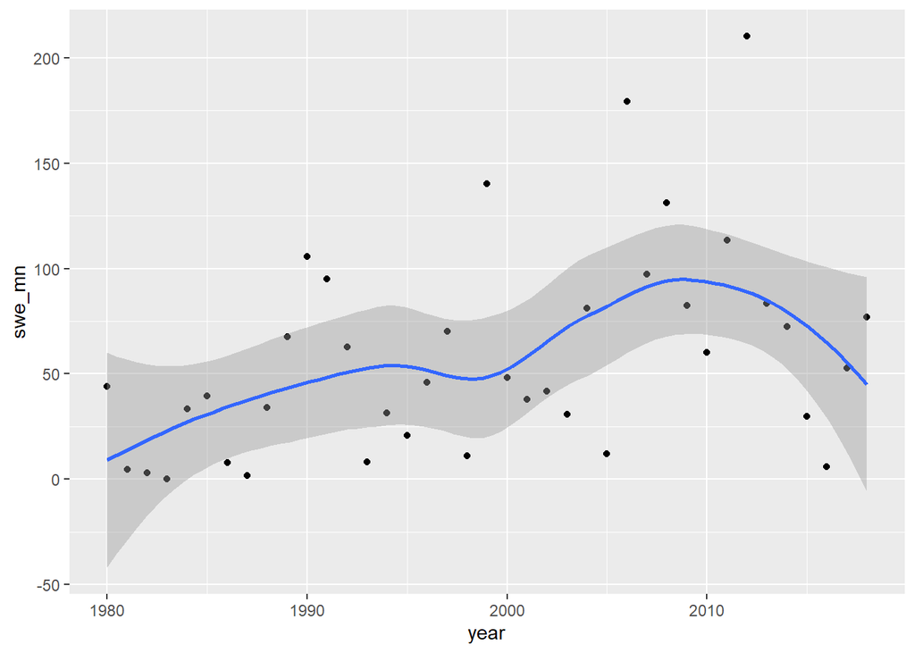

Plot them together to see if snowpack was high during warm years. First plot is scaled data of average air temperature and average swe across the entire watershed by year. Blue is swe and black is air temperature. Second plot is a pairplot of the two sets of scaled data, no real relationship between mean July temperatures and april snowpack, which makes sense.

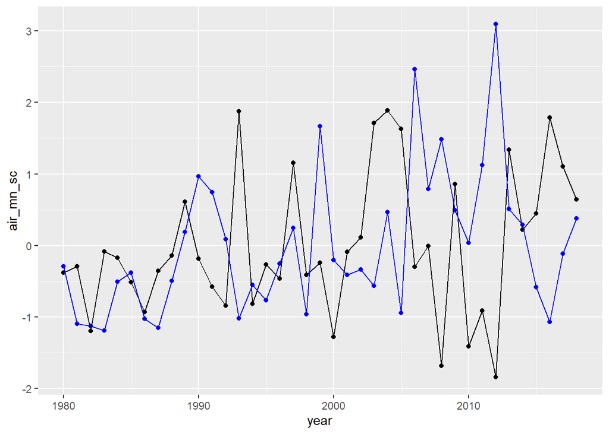

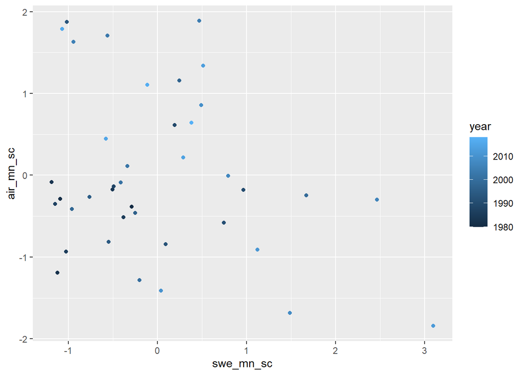